# HRTC Stats

Hunter Ratliff, @HunterRatliff1

1/25/2019

If you’d like the source *data*, reach out to the [BHAR](https://www.utmb.edu/bhar/about-us/bhar-team) office or DM me on [Twitter](https://twitter.com/HunterRatliff1)

```r
knitr::opts_chunk$set(warning=F, message=F, echo=T)

require(MASS)
require(tidyverse)
require(lubridate)
require(readr)
require(ggplot2)
require(knitr)
require(scales)
library(stargazer)

library(lme4)
require(survival)
library(survminer)
library(survMisc)
library(pander)

panderOptions("table.alignment.default", "left")

users <- readRDS("Data/users.RDS") %>%
  mutate(SurvEnd2 = ifelse(SurvEnd > 135, 135, SurvEnd))


HRTC <- readRDS("Data/MergedDf2.RDS") %>%
  mutate(Type = ifelse(campg.day %in% c(26), "Knowledge w/ EX", Type)) %>% # Recode this hotline as MORE
  mutate(Type = ifelse(campg.day %in% c(63,82,86,124), "Knowledge w/ EX", Type)) %>% # Recode this fact as MORE
  filter(campg.day < SurvEnd) %>%
  filter(Type!="Open-ended") %>%
  group_by(userID) %>%
  mutate(userResponses = sum(Replied, na.rm = T)) %>%
  ungroup() %>%
  mutate(
    Type = recode(Type, "Agree/disagree"="T/F"),
    Type = recode(Type, "Knowledge w/ more info"="Knowledge w/ EX")
  )


user.ids <- sample_n(count(HRTC, userID),10)$userID

HRTC[HRTC$mid=="m032",]$Category <- "Partner"
HRTC[HRTC$mid=="m038",]$Category <- "Partner"
HRTC[HRTC$mid=="m061",]$Category <- "Abuse/IPV"

HRTC <- HRTC %>%
  mutate(Tag = Keywords) %>%
  mutate(Tag = ifelse(stringr::str_detect(Tag, "Cyber"), "Cyber", Tag)) %>%
  mutate(Tag = ifelse(stringr::str_detect(Tag, "Consent"), "Consent", Tag)) %>%
  mutate(Tag = ifelse(stringr::str_detect(Tag, "Individuality"), "Individuality", Tag)) %>%
  mutate(Tag = ifelse(stringr::str_detect(Tag, "Stalking"), "Stalking", Tag)) %>%
  mutate(Tag = ifelse(stringr::str_detect(Tag, "Emotional"), "Emotional", Tag))
```

```r
df <- HRTC %>%
  mutate(Replied = as.character(Replied)) %>%
  mutate(
    Replied = recode(Replied, "0"="No"),
    Replied = recode(Replied, "1"="Yes")
    ) %>%
  count(campg.day, Type, Replied) %>%
  spread(Replied, n) %>%
  group_by(Type) %>%
  summarise(Yes = sum(Yes, na.rm=T), No=sum(No, na.rm=T)) %>%
  mutate(
    `Reply %` = Yes/(Yes+No),
    n         = Yes + No
  )

conTable <- as.table(rbind(df$Yes, df$No))
dimnames(conTable) <- list(Replied = c("Yes", "No"),
                           qType = df$Type)
```

# Graph of response rate to each question type

Here’s just an overview of the crude percent of people who responded to each question type:

```r
df %>% mutate(`Reply %` = percent(`Reply %`)) %>% kable()
```

| Type | Yes | No | Reply % | n |
| --- | --- | --- | --- | --- |
| Hotline | 19 | 1725 | 1.1% | 1744 |
| Knowledge | 78 | 4082 | 1.9% | 4160 |
| Knowledge w/ EX | 1318 | 6387 | 17.1% | 7705 |
| Quiz | 818 | 2290 | 26.3% | 3108 |
| T/F | 1482 | 3222 | 31.5% | 4704 |

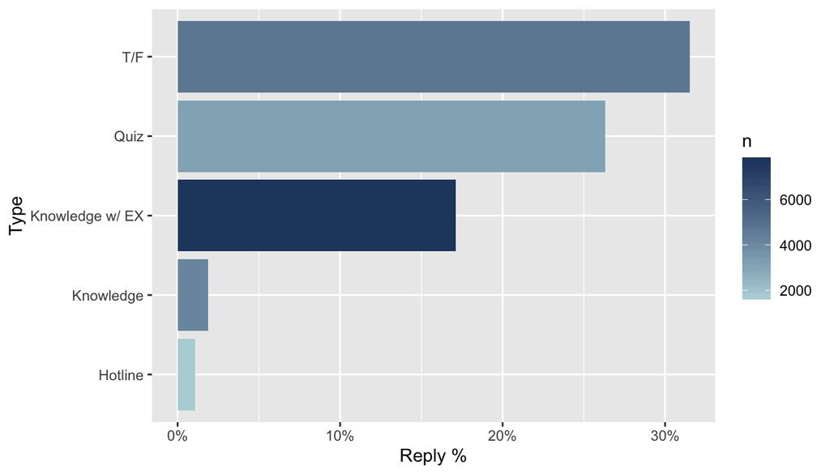

```r
df %>% ggplot(aes(x=Type, y=`Reply %`, fill=n)) +
  geom_col() +
  ggthemes::scale_fill_continuous_tableau(palette = "Blue") +
  scale_y_continuous(labels=percent) + coord_flip()
```

**TODO:** Effect size..?

## Contengency table

Contengency table of responded (yes, no) vs the type of question

```r
kable(conTable)
```

|  | Hotline | Knowledge | Knowledge w/ EX | Quiz | T/F |
| --- | --- | --- | --- | --- | --- |
| Yes | 19 | 78 | 1318 | 818 | 1482 |
| No | 1725 | 4082 | 6387 | 2290 | 3222 |

## Test Results

Here’s the test results

```r
chisq.test(conTable)
##
##  Pearson's Chi-squared test
##
## data:  conTable
## X-squared = 1848.9, df = 4, p-value < 2.2e-16
chisq.test(conTable, simulate.p.value = TRUE, B = 10000)
##
##  Pearson's Chi-squared test with simulated p-value (based on 10000
##  replicates)
##
## data:  conTable
## X-squared = 1848.9, df = NA, p-value = 9.999e-05
```

```r
fifer::chisq.plot(conTable)
```

[output not shown]

## Residuals

```r
chisq.test(conTable)$residuals %>%
  round(2) %>% kable()
```

|  | Hotline | Knowledge | Knowledge w/ EX | Quiz | T/F |
| --- | --- | --- | --- | --- | --- |
| Yes | -16.30 | -23.96 | -0.50 | 12.02 | 23.32 |
| No | 7.47 | 10.97 | 0.23 | -5.50 | -10.68 |

## Post-hoc analysis

Using Fisher’s Exact. Agrees nicely with the results from the logistic regression (next section)

```r
fifer::chisq.post.hoc(t(conTable), control = "bonferroni", digits = 8) %>% pander()
```

```
## Adjusted p-values used the bonferroni method.
```

| comparison | raw.p | adj.p |
| --- | --- | --- |
| Hotline vs. Knowledge | 0.03254 | 0.3254 |
| Hotline vs. Knowledge w/ EX | 0 | 0 |
| Hotline vs. Quiz | 0 | 0 |
| Hotline vs. T/F | 0 | 0 |
| Knowledge vs. Knowledge w/ EX | 0 | 0 |
| Knowledge vs. Quiz | 0 | 0 |
| Knowledge vs. T/F | 0 | 0 |
| Knowledge w/ EX vs. Quiz | 0 | 0 |
| Knowledge w/ EX vs. T/F | 0 | 0 |
| Quiz vs. T/F | 8.6e-07 | 8.57e-06 |

```r
## Fisher's Exact
# fisher.test(conTable,simulate.p.value=TRUE,B=1e7)
fifer::chisq.post.hoc(t(conTable), control = "fdr", digits = 8) %>% pander()
```

```
## Adjusted p-values used the fdr method.
```

| comparison | raw.p | adj.p |
| --- | --- | --- |
| Hotline vs. Knowledge | 0.03254 | 0.03254 |
| Hotline vs. Knowledge w/ EX | 0 | 0 |
| Hotline vs. Quiz | 0 | 0 |
| Hotline vs. T/F | 0 | 0 |
| Knowledge vs. Knowledge w/ EX | 0 | 0 |
| Knowledge vs. Quiz | 0 | 0 |
| Knowledge vs. T/F | 0 | 0 |
| Knowledge w/ EX vs. Quiz | 0 | 0 |
| Knowledge w/ EX vs. T/F | 0 | 0 |
| Quiz vs. T/F | 8.6e-07 | 9.5e-07 |

Note: These regressions are run on students who responded **at least** once

Some resources for binomal regression (for my reference):

- [Logit / Probit](https://www.princeton.edu/~otorres/LogitR101.pdf)
- [Multilevel Modeling in R](https://rpubs.com/rslbliss/r_mlm_ws)
- [Intro to Generalized linear mixed models](https://stats.idre.ucla.edu/r/dae/mixed-effects-logistic-regression/)

Run a bimodal regression based on `Question type` + `grade` + `race` + `gender` + `number of user's responses` + `Campaign number` (e.g. is it the first message sent, second sent, last message sent in the campaign). *In the future, can look at how category and/or keywords play into this.*

```r
df <- HRTC %>%
  filter(userResponses>0) %>%
  # filter(Type!="Knowledge") %>%
  mutate(Dummy = as.factor(zipcode)) %>%
  mutate(userID = as.factor(userID)) %>%
  mutate(Category = as.factor(Category)) %>%
  mutate(Replied = ifelse(Replied==1, "Yes", "No")) %>%
  mutate(Replied = factor(Replied, levels=c("No","Yes")))

mod <- glm(Replied ~ Type + grade + race + gender + userResponses + campg.num,
           data=df, family=binomial(link = "logit"))
# round(exp(coef(mod)),4)
```

```r
pander(mod)
```

Fitting generalized (binomial/logit) linear model: Replied ~ Type + grade + race + gender + userResponses + campg.num

|  | Estimate | Std. Error | z value | Pr(>\|z\|) |
| --- | --- | --- | --- | --- |
| **(Intercept)** | -6.354 | 0.3701 | -17.17 | 4.606e-66 |
| **TypeKnowledge** | 0.3154 | 0.3071 | 1.027 | 0.3044 |
| **TypeKnowledge w/ EX** | 3.931 | 0.2709 | 14.51 | 1.009e-47 |
| **TypeQuiz** | 4.912 | 0.2784 | 17.64 | 1.197e-69 |
| **TypeT/F** | 5.029 | 0.2737 | 18.38 | 2.05e-75 |
| **grade11** | -0.09469 | 0.08896 | -1.064 | 0.2871 |
| **grade12** | -0.0538 | 0.08536 | -0.6303 | 0.5285 |
| **grade7** | 0.07815 | 0.1302 | 0.6004 | 0.5482 |
| **grade8** | 0.03561 | 0.1804 | 0.1974 | 0.8435 |
| **grade9** | -0.095 | 0.0932 | -1.019 | 0.3081 |
| **raceAsian** | 0.1379 | 0.2794 | 0.4937 | 0.6215 |
| **raceBlack** | 0.2564 | 0.2511 | 1.021 | 0.3072 |
| **raceHispanic** | 0.1618 | 0.2426 | 0.6667 | 0.505 |
| **raceOther** | 0.2364 | 0.2966 | 0.797 | 0.4254 |
| **raceWhite** | 0.1511 | 0.2419 | 0.6248 | 0.5321 |
| **genderMale** | -0.008795 | 0.06531 | -0.1347 | 0.8929 |
| **genderOther** | -0.1408 | 0.3921 | -0.3591 | 0.7195 |
| **userResponses** | 0.1489 | 0.003566 | 41.76 | 0 |
| **campg.num** | -0.03787 | 0.002095 | -18.08 | 4.631e-73 |

```r
# summary(mod)
mod.table <- as.data.frame(summary(mod)$coefficients) %>%
  mutate(`Exp(Estimate)` = exp(Estimate))

mod.exp.ci <- exp(confint(mod)) # Using MASS package

x <- cbind(mod.table, mod.exp.ci) %>%
  rownames_to_column() %>%
  mutate_if(is.double, round, 4) %>%
  rename(`Exp(B) Lower95CI`=`2.5 %`) %>%
  rename(`Exp(B) Upper95CI`=`97.5 %`) %>%
  column_to_rownames() %>%
  as.matrix()

# mod.summary <- summary(mod)
# mod.summary$coefficients <- x
# mod.summary
pander(x)
```

Table continues below

|  | Estimate | Std. Error | z value | Pr(>\|z\|) |
| --- | --- | --- | --- | --- |
| **(Intercept)** | -6.354 | 0.3701 | -17.17 | 0 |
| **TypeKnowledge** | 0.3154 | 0.3071 | 1.027 | 0.3044 |
| **TypeKnowledge w/ EX** | 3.931 | 0.2709 | 14.51 | 0 |
| **TypeQuiz** | 4.912 | 0.2784 | 17.64 | 0 |
| **TypeT/F** | 5.029 | 0.2737 | 18.38 | 0 |
| **grade11** | -0.0947 | 0.089 | -1.065 | 0.2871 |
| **grade12** | -0.0538 | 0.0854 | -0.6303 | 0.5285 |
| **grade7** | 0.0782 | 0.1302 | 0.6004 | 0.5482 |
| **grade8** | 0.0356 | 0.1804 | 0.1974 | 0.8435 |
| **grade9** | -0.095 | 0.0932 | -1.019 | 0.3081 |
| **raceAsian** | 0.1379 | 0.2794 | 0.4937 | 0.6215 |
| **raceBlack** | 0.2564 | 0.2511 | 1.021 | 0.3072 |
| **raceHispanic** | 0.1618 | 0.2426 | 0.6667 | 0.505 |
| **raceOther** | 0.2364 | 0.2966 | 0.797 | 0.4254 |
| **raceWhite** | 0.1511 | 0.2419 | 0.6248 | 0.5321 |
| **genderMale** | -0.0088 | 0.0653 | -0.1347 | 0.8929 |
| **genderOther** | -0.1408 | 0.3921 | -0.3591 | 0.7195 |
| **userResponses** | 0.1489 | 0.0036 | 41.76 | 0 |
| **campg.num** | -0.0379 | 0.0021 | -18.08 | 0 |

|  | Exp(Estimate) | Exp(B) Lower95CI | Exp(B) Upper95CI |
| --- | --- | --- | --- |
| **(Intercept)** | 0.0017 | 8e-04 | 0.0035 |
| **TypeKnowledge** | 1.371 | 0.7659 | 2.572 |
| **TypeKnowledge w/ EX** | 50.95 | 30.93 | 90.02 |
| **TypeQuiz** | 135.9 | 81.14 | 243.2 |
| **TypeT/F** | 152.7 | 92.17 | 271.1 |
| **grade11** | 0.9097 | 0.7641 | 1.083 |
| **grade12** | 0.9476 | 0.8017 | 1.12 |
| **grade7** | 1.081 | 0.8364 | 1.393 |
| **grade8** | 1.036 | 0.7232 | 1.468 |
| **grade9** | 0.9094 | 0.7574 | 1.091 |
| **raceAsian** | 1.148 | 0.6644 | 1.988 |
| **raceBlack** | 1.292 | 0.7918 | 2.121 |
| **raceHispanic** | 1.176 | 0.7322 | 1.897 |
| **raceOther** | 1.267 | 0.7072 | 2.264 |
| **raceWhite** | 1.163 | 0.7257 | 1.875 |
| **genderMale** | 0.9912 | 0.8718 | 1.126 |
| **genderOther** | 0.8687 | 0.3736 | 1.771 |
| **userResponses** | 1.161 | 1.153 | 1.169 |
| **campg.num** | 0.9628 | 0.9589 | 0.9668 |

```r
rm(mod.table, mod.exp.ci, x)
```

```r
stargazer(mod, type='latex', title="Log-odds",
          single.row=T, intercept.top=T, intercept.bottom=F)
```

[output not shown]

```r
# stargazer(mod, coef=list(exp(coef(mod))), p.auto=FALSE, type = 'latex',
#           single.row=T, intercept.top=T, intercept.bottom=F, title="Exponential Log odds")
stargazer(mod, apply.coef=exp, apply.se=exp, type="latex", p.auto=F,
          single.row=T, intercept.top=T, intercept.bottom=F, title="Exponential of Log odds")
```

[output not shown]

```r
summary(mod)
```

[output not shown]

```r
anova(mod, test="Chisq") #see ?anova.glm
par(mfrow = c(2, 2))
plot(mod)
```

[output not shown]

### Prediction

Based on modeling only the significant variables from above, which has a higher AIC (second model’s AIC=`12,331`) than the model above (AIC=`8,090`). Note that the figure shows three points in time (beginning, midpoint, and end), but assumes `userResponses` is the same across the board

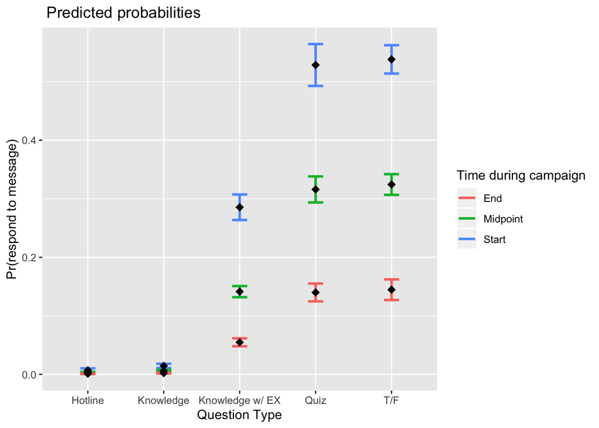

```r
mod2 <- glm(Replied ~ Type + userResponses + campg.num,
           data=df, family=binomial(link = "logit"))

newDf <- data.frame(
  userResponses = rep(mean(df$userResponses),15),
  campg.num     = c(rep(min(df$campg.num),5), rep(mean(df$campg.num),5), rep(max(df$campg.num),5)),
  Time          = c(rep("Start",5), rep("Midpoint",5), rep("End",5)),
  Type = rep(unique(df$Type),3)
)

cbind(newDf, predict(mod2, newdata=newDf, type="response", se.fit=TRUE)) %>%
  rename(prob=fit, se.prob=se.fit) %>%
  mutate(
    ll = prob - 1.96*se.prob,
    ul = prob + 1.96*se.prob,
  ) %>%
  ggplot(aes(x=Type, y = prob)) +
  geom_errorbar(aes(ymin = ll, ymax = ul, color=Time), width = 0.2, lty=1, lwd=1) +
  geom_point(shape=18, size=3, fill="black") +
  scale_color_discrete(name="Time during campaign") +
  labs(title= " Predicted probabilities", x="Question Type", y="Pr(respond to message)")
```

```r
rm(newDf, mod2)
```

```r
df <- HRTC %>%
  filter(userResponses>0) %>%
  mutate(Dummy = as.factor(zipcode)) %>%
  mutate(userID = as.factor(userID)) %>%
  mutate(Replied = ifelse(Replied==1, "Yes", "No")) %>%
  mutate(Replied = factor(Replied, levels=c("No","Yes")))

multiMod <- glmer(Replied ~ Type + (1 | userID),
                  data=df, family=binomial(link = "logit"))
                  # control=glmerControl(optimizer = "bobyqa", optCtrl = list(maxfun = 10000)))

summary(multiMod)
```

```
## Generalized linear mixed model fit by maximum likelihood (Laplace
##   Approximation) [glmerMod]
##  Family: binomial  ( logit )
## Formula: Replied ~ Type + (1 | userID)
##    Data: df
##
##      AIC      BIC   logLik deviance df.resid
##  12952.6  12999.4  -6470.3  12940.6    18068
##
## Scaled residuals:
##     Min      1Q  Median      3Q     Max
## -4.1588 -0.3957 -0.1975 -0.0403 24.7967
##
## Random effects:
##  Groups Name        Variance Std.Dev.
##  userID (Intercept) 2.119    1.456
## Number of obs: 18074, groups:  userID, 414
##
## Fixed effects:
##                     Estimate Std. Error z value Pr(>|z|)
## (Intercept)          -5.3448     0.2489 -21.474   <2e-16 ***
## TypeKnowledge         0.5810     0.2626   2.212   0.0269 *
## TypeKnowledge w/ EX   3.4863     0.2392  14.572   <2e-16 ***
## TypeQuiz              4.2730     0.2426  17.613   <2e-16 ***
## TypeT/F               4.7069     0.2411  19.524   <2e-16 ***
## ---
## Signif. codes:  0 '***' 0.001 '**' 0.01 '*' 0.05 '.' 0.1 ' ' 1
##
## Correlation of Fixed Effects:
##             (Intr) TypKnw TKw/EX TypeQz
## TypeKnowldg -0.842
## TypKnwlw/EX -0.942  0.876
## TypeQuiz    -0.934  0.864  0.967
## TypeT/F     -0.943  0.870  0.974  0.966
```

```r
# Basic        AIC = 11,174
# Gender       AIC = 8,037
# Grade        AIC = 7,861 (no convergence)
# Race         AIC = 8,105 (no convergence)
# Gender grade AIC = 7,574 (no convergence)
```

```r
plot(multiMod)
lattice::qqmath(multiMod)
```

[output not shown]

```r
# Consider using broom::augment.glm()
newDf <- data.frame(
  userID = unique(df$userID),
  Type = rep(unique(df$Type),414)
)

cbind(newDf, prob=predict(multiMod, newdata=newDf)) %>%
  mutate(prob= exp(prob)) %>%
  filter(prob<1) %>%
  ggplot(aes(x=Type, y=prob)) + geom_boxplot(varwidth=T)
```

[output not shown]

Some resources for survival analysis (for my reference):

- [Comparing survival times between groups](https://www.emilyzabor.com/tutorials/survival_analysis_in_r_tutorial.html#comparing_survival_times_between_groups)

## Gender

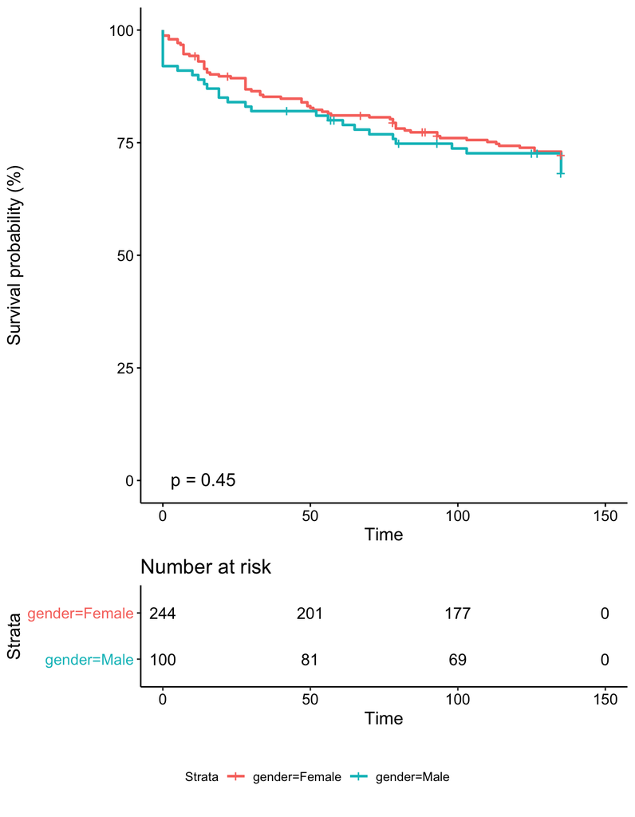

```r
df <- users %>%
  filter(gender!="Other")
survObj <- Surv(time=df$SurvEnd2, event=df$Censor)

survfit(survObj ~ gender, data = df) %>%
  ggsurvplot(data = df, pval=T, #conf.int=T,
             risk.table = TRUE,
             fun = "pct",
             size = 1,
             legend = "bottom")
```

```r
  # ggsurv() +
  # scale_y_continuous(labels = scales::percent) +
  # scale_x_continuous(name="Days into campaign") +
  # scale_color_brewer(palette="Set2", na.value = "grey50")
```

## Grade

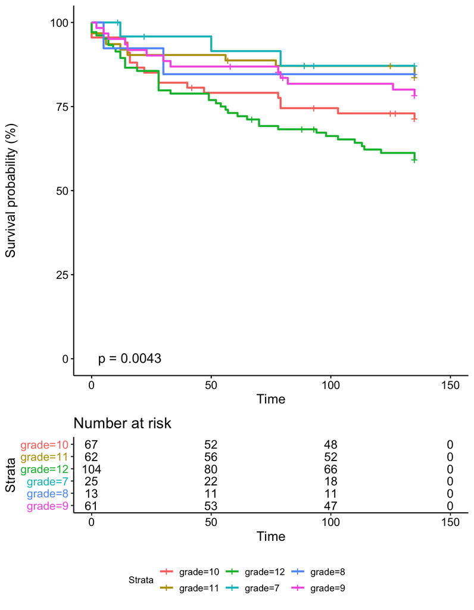

```r
df <- users  %>%
  filter(grade!="other")
survObj <- Surv(time=df$SurvEnd2, event=df$Censor)

survfit(survObj ~ grade, data = df) %>%
  ggsurvplot(data = df, pval=T, #conf.int=T,
             risk.table = TRUE,
             fun = "pct",
             size = 1,
             legend = "bottom")
```

## Race

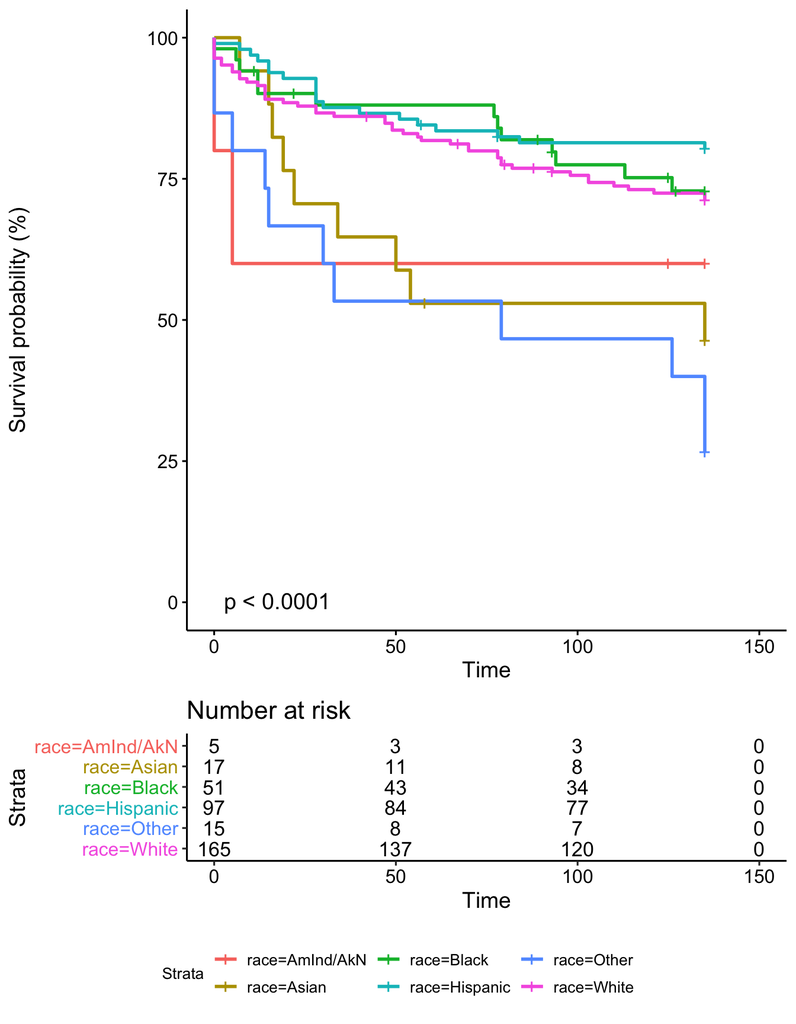

```r
df <- users
survObj <- Surv(time=df$SurvEnd2, event=df$Censor)

survfit(survObj ~ race, data = df) %>%
  ggsurvplot(data = df, pval=T, #conf.int=T,
             risk.table = TRUE,
             fun = "pct",
             size = 1,
             legend = "bottom")
```

## Combo

```r
df <- users  %>%
  filter(grade!="other", gender!="Other")
survObj <- Surv(time=df$SurvEnd2, event=df$Censor)

# Fit a Cox proportional hazards model
coxph(survObj ~ grade + race, data=df) %>% summary()
```

[output not shown]

```r
# Export to SPSS
# HRTC %>% filter(userResponses>1) %>% select(userID, message_id, Type, mid, Replied:userResponses) %>% write_csv("~/Downloads/data.csv")
```

So there’s quite a few `NA`’s (people who didn’t have their gender, grade, or race recorded). A few people did respond to the gender & grade questions, but didn’t fit into a larger category, so I dropped them from the analysis (total of 7 students)

Total number of students: **525**

## Gender

```r
users %>%
  semi_join(count(HRTC, userID)) %>%
  count(gender, sort=T) %>%

  mutate(sansNA = ifelse(is.na(gender),0,n)) %>%
  mutate(gender = ifelse(is.na(gender),"NA",as.character(gender))) %>%
  filter(gender!="Other") %>%
  mutate(sansNA = percent(sansNA/sum(sansNA))) %>%
  mutate(Percent = percent(n/sum(n))) %>%

  # select(gender, n, Percent, sansNA) %>%
  kable()
```

| gender | n | sansNA | Percent |
| --- | --- | --- | --- |
| Female | 238 | 72.1% | 45.9% |
| NA | 189 | 0.0% | 36.4% |
| Male | 92 | 27.9% | 17.7% |

## Grade

```r
users %>%
  semi_join(count(HRTC, userID)) %>%
  count(grade, sort=T) %>%

  mutate(sansNA = ifelse(is.na(grade),0,n)) %>%
  mutate(grade = ifelse(is.na(grade),"NA",as.character(grade))) %>%
  filter(grade!="other") %>%
  mutate(sansNA = percent(sansNA/sum(sansNA))) %>%
  mutate(Percent = percent(n/sum(n))) %>%

  kable()
```

| grade | n | sansNA | Percent |
| --- | --- | --- | --- |
| NA | 207 | 0.0% | 39.5% |
| 12 | 99 | 31.2% | 18.9% |
| 10 | 64 | 20.2% | 12.2% |
| 11 | 58 | 18.3% | 11.1% |
| 9 | 58 | 18.3% | 11.1% |
| 7 | 25 | 7.9% | 4.8% |
| 8 | 13 | 4.1% | 2.5% |

## Race

Note that unlike gender & grade, I didn’t drop the `Other` race because it’s representing `Two or more races`

```r
users %>%
  semi_join(count(HRTC, userID)) %>%
  count(race, sort=T) %>%

  mutate(sansNA = ifelse(is.na(race),0,n)) %>%
  mutate(race = ifelse(is.na(race),"NA",as.character(race))) %>%
  mutate(sansNA = percent(sansNA/sum(sansNA))) %>%
  mutate(Percent = percent(n/sum(n))) %>%

  kable()
```

| race | n | sansNA | Percent |
| --- | --- | --- | --- |
| NA | 189 | 0.0% | 36.0% |
| White | 157 | 46.7% | 29.9% |
| Hispanic | 96 | 28.6% | 18.3% |
| Black | 50 | 14.9% | 9.5% |
| Asian | 17 | 5.1% | 3.2% |
| Other | 12 | 3.6% | 2.3% |
| AmInd/AkN | 4 | 1.2% | 0.8% |

```r
data_frame(
  Race = c("White (non-Hispanic)", "Hispanic or Latino",
           "Black or African American", "Asian", "Two or more races",
           "American Indian and Alaska Native"),
  Percent = c(0.459, 0.287, 0.208, 0.032, 0.025, 0.005)
) %>%
  mutate(Percent = percent(Percent)) %>%
  # arrange(desc(Percent))
  kable()
```

| Race | Percent |
| --- | --- |
| White (non-Hispanic) | 45.9% |
| Hispanic or Latino | 28.7% |
| Black or African American | 20.8% |
| Asian | 3.2% |
| Two or more races | 2.5% |
| American Indian and Alaska Native | 0.5% |

**R version 3.3.2 (2016-10-31)**

**Platform:** x86_64-apple-darwin13.4.0 (64-bit)

**locale:** en_US.UTF-8||en_US.UTF-8||en_US.UTF-8||C||en_US.UTF-8||en_US.UTF-8

**attached base packages:** *stats*, *graphics*, *grDevices*, *utils*, *datasets*, *methods* and *base*

**other attached packages:** *bindrcpp(v.0.2.2)*, *pander(v.0.6.3)*, *survMisc(v.0.5.5)*, *survminer(v.0.4.3)*, *ggpubr(v.0.2)*, *magrittr(v.1.5)*, *survival(v.2.40-1)*, *lme4(v.1.1-19)*, *Matrix(v.1.2-7.1)*, *stargazer(v.5.2.2)*, *scales(v.0.5.0)*, *knitr(v.1.18)*, *lubridate(v.1.7.1)*, *forcats(v.0.2.0)*, *stringr(v.1.2.0)*, *dplyr(v.0.7.8)*, *purrr(v.0.2.4)*, *readr(v.1.1.1)*, *tidyr(v.0.7.2)*, *tibble(v.1.4.2)*, *ggplot2(v.3.1.0.9000)*, *tidyverse(v.1.2.1)* and *MASS(v.7.3-45)*

**loaded via a namespace (and not attached):** *TH.data(v.1.0-10)*, *minqa(v.1.2.4)*, *colorspace(v.1.3-2)*, *modeltools(v.0.2-21)*, *rprojroot(v.1.3-2)*, *estimability(v.1.3)*, *htmlTable(v.1.13.1)*, *base64enc(v.0.1-3)*, *rstudioapi(v.0.7)*, *mice(v.2.46.0)*, *fifer(v.1.1)*, *mvtnorm(v.1.0-5)*, *coin(v.1.2-2)*, *xml2(v.1.1.1)*, *codetools(v.0.2-15)*, *splines(v.3.3.2)*, *spam(v.2.1-2)*, *Formula(v.1.2-3)*, *jsonlite(v.1.5)*, *nloptr(v.1.2.1)*, *broom(v.0.5.1.9000)*, *km.ci(v.0.5-2)*, *cluster(v.2.0.5)*, *httr(v.1.3.1)*, *randomForestSRC(v.2.5.1)*, *lsmeans(v.2.30-0)*, *emmeans(v.1.3.2)*, *backports(v.1.1.2)*, *assertthat(v.0.2.0)*, *lazyeval(v.0.2.1)*, *strucchange(v.1.5-1)*, *cli(v.1.0.1)*, *acepack(v.1.4.1)*, *htmltools(v.0.3.6)*, *tools(v.3.3.2)*, *dotCall64(v.0.9-5)*, *gtable(v.0.2.0)*, *glue(v.1.2.0)*, *ggthemes(v.3.3.0)*, *maps(v.3.1.1)*, *Rcpp(v.1.0.0)*, *cellranger(v.1.1.0)*, *nlme(v.3.1-128)*, *rvest(v.0.3.2)*, *zoo(v.1.8-4)*, *hms(v.0.4.0)*, *parallel(v.3.3.2)*, *sandwich(v.2.5-0)*, *RColorBrewer(v.1.1-2)*, *fields(v.9.0)*, *yaml(v.2.1.16)*, *gridExtra(v.2.2.1)*, *KMsurv(v.0.1-5)*, *rpart(v.4.1-10)*, *latticeExtra(v.0.6-28)*, *stringi(v.1.1.6)*, *highr(v.0.6)*, *plotrix(v.3.7-4)*, *randomForest(v.4.6-12)*, *checkmate(v.1.9.1)*, *rlang(v.0.3.0.1)*, *pkgconfig(v.2.0.2)*, *evaluate(v.0.10)*, *lattice(v.0.20-34)*, *bindr(v.0.1.1)*, *htmlwidgets(v.1.3)*, *labeling(v.0.3)*, *cmprsk(v.2.2-7)*, *cowplot(v.0.9.3)*, *tidyselect(v.0.2.3)*, *plyr(v.1.8.4)*, *R6(v.2.2.2)*, *generics(v.0.0.2)*, *Hmisc(v.4.1-1)*, *multcomp(v.1.4-8)*, *pillar(v.1.3.1)*, *haven(v.1.1.0)*, *foreign(v.0.8-67)*, *withr(v.2.1.2)*, *nnet(v.7.3-12)*, *modelr(v.0.1.1)*, *crayon(v.1.3.4)*, *party(v.1.2-4)*, *rmarkdown(v.1.8)*, *grid(v.3.3.2)*, *readxl(v.1.0.0)*, *data.table(v.1.10.4-3)*, *digest(v.0.6.13)*, *xtable(v.1.8-2)*, *stats4(v.3.3.2)* and *munsell(v.0.5.0)*